# Assignment 3: Comparing groups

Your-name-here

2023-03-13

## Problem 1: Price of wine *(7pts)*

Every year, Wine Magazine publishes information on wines sold in the US. A subset of the data is available in the `wine` dataset, which contains inforamtion on 150 randomly selected wines from each of three countries: France, Italy, and the US. We are interested in knowing whether wines from the three countries differ in price.

Start by loading the dataset:

```r
wine <- read.csv("winemag-subsetdata.csv")
```

#### Q1.1. Visualize the distribution of `price` across each of the three countries. There are multiple possible ways to do this!

*(1pt)*

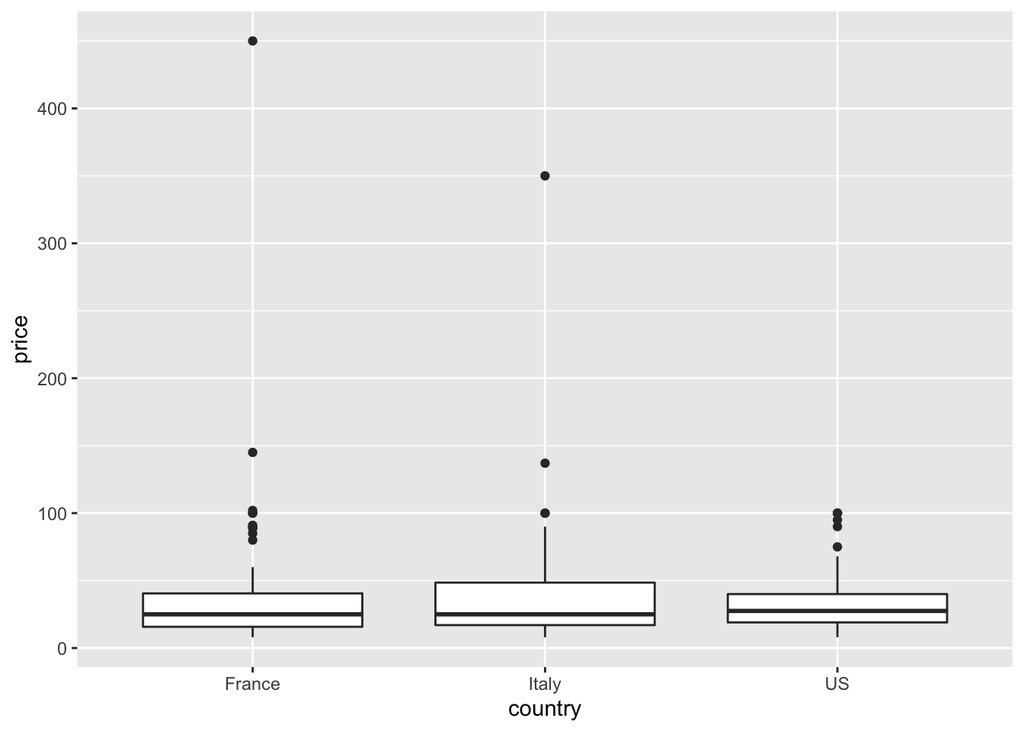

```r
ggplot(wine, aes(x = country, y = price))+
  geom_boxplot()
```

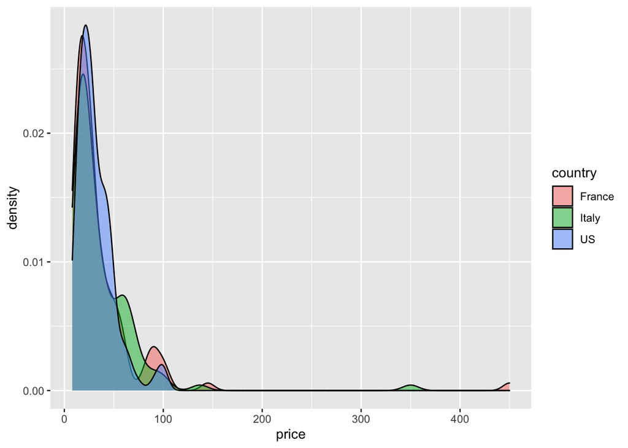

```r
ggplot(wine, aes(x = price, fill = country))+
  geom_density(alpha = 0.5)
```

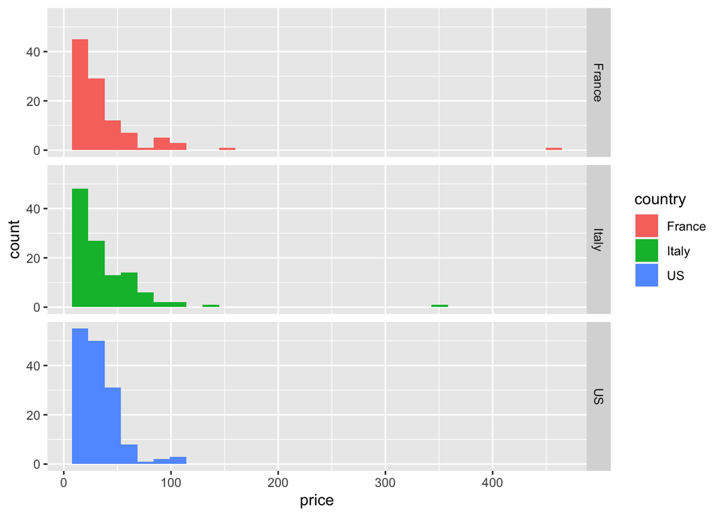

```r
ggplot(wine, aes(x = price, fill = country))+
  geom_histogram()+
  facet_grid(country~.)
```

#### Q1.2. Based on your visualization, do the data look normally distributed? Use an appropriate statistical test to check this.

*(2pts)*

No

```r
shapiro.test(wine$price[wine$country == "France"])
```

```
##
##  Shapiro-Wilk normality test
##
## data:  wine$price[wine$country == "France"]
## W = 0.45028, p-value < 2.2e-16
```

```r
shapiro.test(wine$price[wine$country == "Italy"])
```

```
##
##  Shapiro-Wilk normality test
##
## data:  wine$price[wine$country == "Italy"]
## W = 0.55897, p-value < 2.2e-16
```

```r
shapiro.test(wine$price[wine$country == "US"])
```

```
##
##  Shapiro-Wilk normality test
##
## data:  wine$price[wine$country == "US"]
## W = 0.85866, p-value = 1.092e-10
```

#### Q1.3. Based on the results of your tests, and what you know about the variables you are interested in, what kind of test should you use?

*(1pt)*

Kruskal Wallis

#### Q1.4. State your null and alternate hypotheses

*(1pt)*

H<sub>0</sub>: The groups do not differ in median price H<sub>1</sub>: The groups differ in median price

#### Q1.5. Conduct the test

*(1pt)*

```r
kruskal.test(price ~ country, data = wine)
```

```
##
##  Kruskal-Wallis rank sum test
##
## data:  price by country
## Kruskal-Wallis chi-squared = 0.9757, df = 2, p-value = 0.6139
```

#### Q1.6. Conclude on your null hypothesis

*(1pt)*

We fail to reject the null

## Problem 2: Height in the MLB *(8pts)*

We have a dataset which lists the heights and weights of players in the MLB according to the position that they play. We are interested in differences in height between starting pitchers and first basemen.

#### Q2.1. Read in the data, and trim it down to contain only the players who play either as starting pitchers or first baseman

*(1pt)*

```r
mlb <- read.csv("MLB-anthrops.csv")
mlb <- mlb %>%
  filter(position %in% c("Starting_Pitcher", "First_Baseman"))
```

#### Q2.2. Plot the distribution of `height` across the positions. There are multiple possible ways to do this!

*(1pt)*

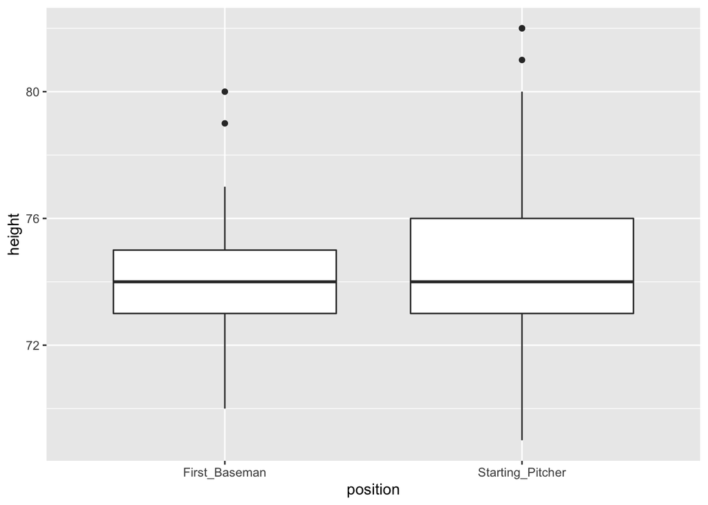

```r
ggplot(mlb, aes(x = position, y = height))+
  geom_boxplot()
```

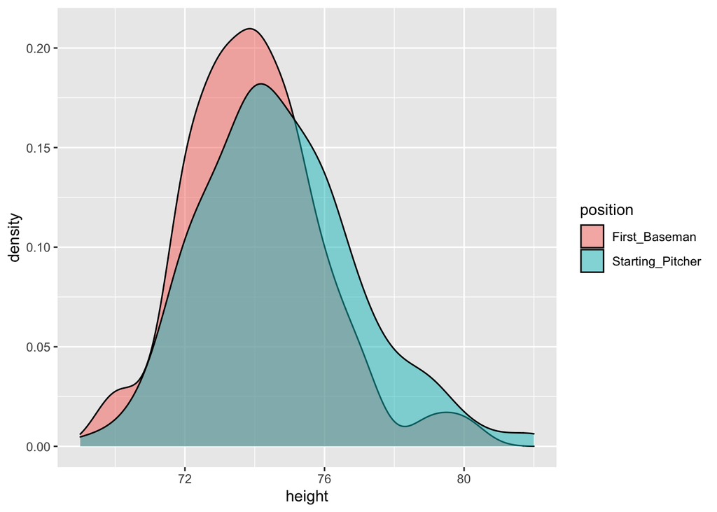

```r
ggplot(mlb, aes(x = height, fill = position))+
  geom_density(alpha = 0.5)
```

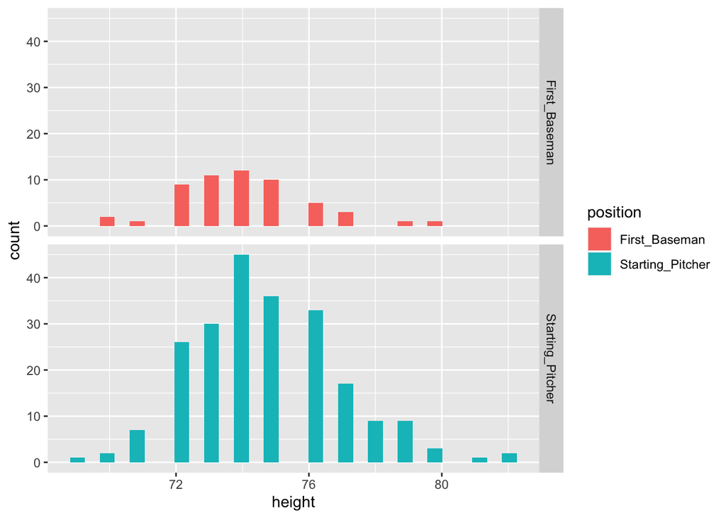

```r
ggplot(mlb, aes(x = height, fill = position))+
  geom_histogram()+
  facet_grid(position~.)
```

#### Q2.3. Based on your visualization, do the data look normally distributed? Use an appropriate statistical test to check this.

*(2pt)*

No

```r
shapiro.test(mlb$height[mlb$position == "Starting_Pitcher"])
```

```
##
##  Shapiro-Wilk normality test
##
## data:  mlb$height[mlb$position == "Starting_Pitcher"]
## W = 0.96581, p-value = 3.605e-05
```

```r
shapiro.test(mlb$height[mlb$position == "First_Baseman"])
```

```
##
##  Shapiro-Wilk normality test
##
## data:  mlb$height[mlb$position == "First_Baseman"]
## W = 0.95166, p-value = 0.02725
```

#### Q2.4. Based on the results of your tests, and what you know about the variables you are interested in, what kind of test should you use?

*(1pt)*

Mann Whitney/Wilcoxon

#### Q2.5. State your null and alternate hypotheses

*(1pt)*

#### Q1.5. Conduct the test

*(1pt)*

```r
wilcox.test(height ~ position, data = mlb)
```

```
##
##  Wilcoxon rank sum test with continuity correction
##
## data:  height by position
## W = 4940.5, p-value = 0.03005
## alternative hypothesis: true location shift is not equal to 0
```

#### Q1.6. Conclude on your null hypothesis

*(1pt)*

We reject the null

## Problem 3: Sodium intake across three groups *(11pts)*

Three groups of students have been taking nutrition classes. Each group is taught by a different instructor, who is teaching slightly different content. We want to know if the content of each version of the course has influenced the students differently. Specifically, we want to know whether sodium intake varies across the students who take different versions of the course.

The data are contained in the `nutrition` dataset

```r
nutrition <- read.csv("class-nutrition.csv")
```

#### Q3.1. Visualize the distribution of `sodium` across each of the three classes There are multiple possible ways to do this!

*(1pt)*

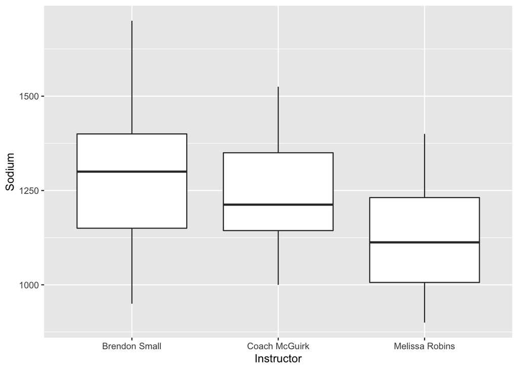

```r
ggplot(nutrition, aes(x = Instructor, y = Sodium))+
  geom_boxplot()
```

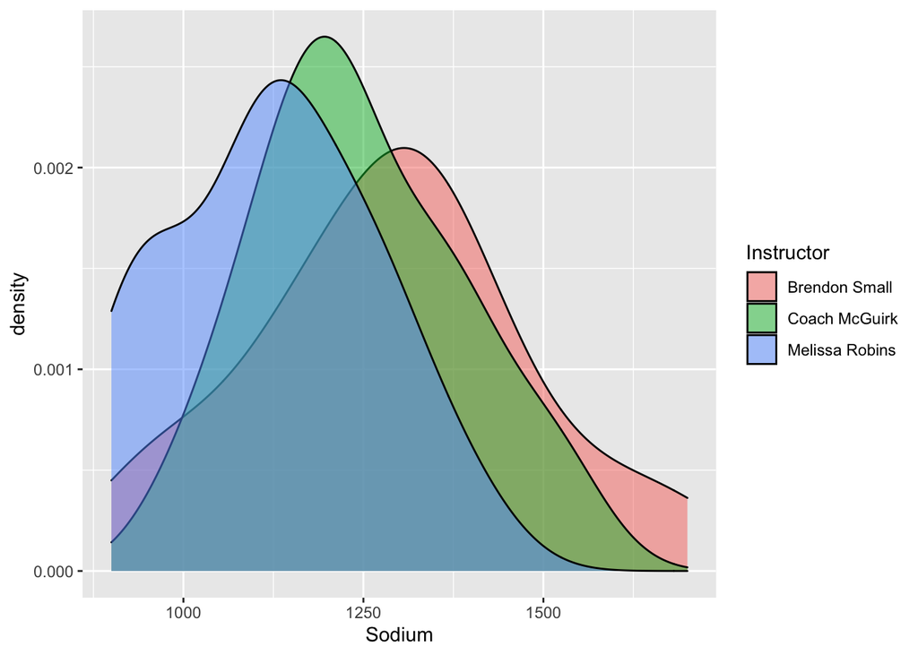

```r
ggplot(nutrition, aes(x = Sodium, fill = Instructor))+
  geom_density(alpha = 0.5)
```

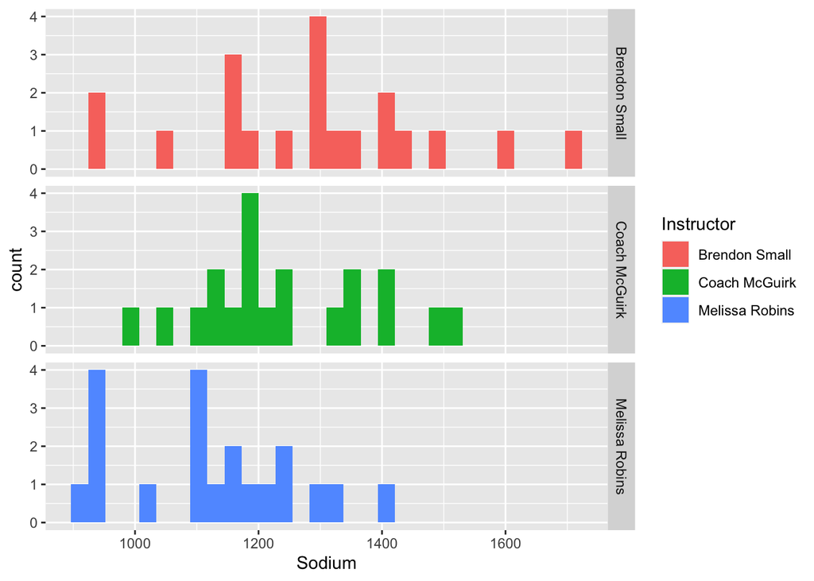

```r
ggplot(nutrition, aes(x = Sodium, fill = Instructor))+
  geom_histogram()+
  facet_grid(Instructor~.)
```

#### Q3.2. Based on your visualization, do the data look normally distributed? Use an appropriate statistical test to check this.

*(2pt)*

```r
shapiro.test(nutrition$Sodium[nutrition$Instructor == "Brendon Small"])
```

```
##
##  Shapiro-Wilk normality test
##
## data:  nutrition$Sodium[nutrition$Instructor == "Brendon Small"]
## W = 0.97212, p-value = 0.7989
```

```r
shapiro.test(nutrition$Sodium[nutrition$Instructor == "Coach McGuirk"])
```

```
##
##  Shapiro-Wilk normality test
##
## data:  nutrition$Sodium[nutrition$Instructor == "Coach McGuirk"]
## W = 0.96772, p-value = 0.7062
```

```r
shapiro.test(nutrition$Sodium[nutrition$Instructor == "Melissa Robins"])
```

```
##
##  Shapiro-Wilk normality test
##
## data:  nutrition$Sodium[nutrition$Instructor == "Melissa Robins"]
## W = 0.95835, p-value = 0.5114
```

#### Q3.3. Based on the results of your tests, and what you know about the variables you are interested in, what kind of test should you use?

*(1pt)*

ANOVA

#### Q3.4. State your null and alternate hypotheses

*(1pt)*

H<sub>0</sub>: The groups do not differ in mean sodium intake H<sub>1</sub>: The groups differ in mean sodium intake

#### Q3.5. Check any additional assumptions needed

*(1pt)*

```r
leveneTest(Sodium ~ Instructor, data = nutrition)
```

```
## Levene's Test for Homogeneity of Variance (center = median)
##       Df F value Pr(>F)
## group  2  0.5694 0.5691
##       57
```

#### Q3.6. Given this additional assumption check, which test will you use?

*(1pt)*

ANOVA

#### Q3.7. Run the test

*(1pt)*

```r
anov <- aov(Sodium ~ Instructor, data = nutrition)
summary(anov)
```

```
##             Df  Sum Sq Mean Sq F value  Pr(>F)
## Instructor   2  290146  145073   5.558 0.00624 **
## Residuals   57 1487812   26102
## ---
## Signif. codes:  0 '***' 0.001 '**' 0.01 '*' 0.05 '.' 0.1 ' ' 1
```

#### Q3.8. Conclude on your null hypothesis

*(1pt)*

#### Q3.9. Conduct any post-hoc testing necessary. Which group(s) seem to be different?

*(2pt)*

```r
TukeyHSD(anov)
```

```
##   Tukey multiple comparisons of means
##     95% family-wise confidence level
##
## Fit: aov(formula = Sodium ~ Instructor, data = nutrition)
##
## $Instructor
##                                 diff       lwr         upr     p adj
## Coach McGuirk-Brendon Small   -41.25 -164.1941  81.6941219 0.7000083
## Melissa Robins-Brendon Small -163.75 -286.6941 -40.8058781 0.0061739
## Melissa Robins-Coach McGuirk -122.50 -245.4441   0.4441219 0.0510271
```